# Exercise 2

Zhiqian Chen, Yi Zeng, Qihang Liang

3/11/2021

##Problem 1: visualization

#A) One panel of line graphs that plots average boarding grouped by hour of the day, day of week, and month. Facet by day of week.

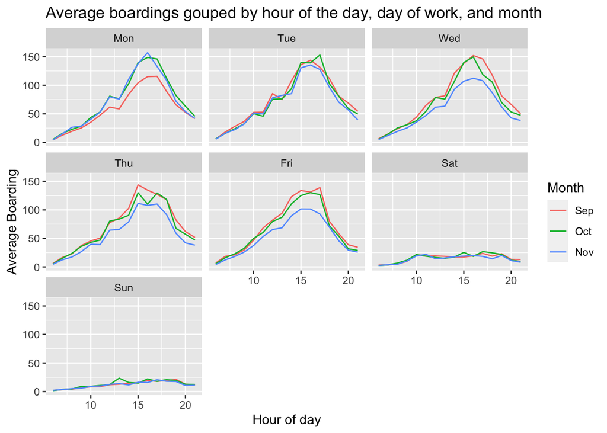

The graph whows that the it broadly similar across days for weekday or weekend. But there is a big bifferent between weekday and weekend.

The average boardings on Mondays in September look lower. The reason may be the hot weather in September, and the students don’t want to board compare to other month. The other reason is that there is a holiday on monday in september. The average boardings on Weds/Thurs/Fri in November look lower. This may because the cold weather in November, students don’t want to board compare to other month. The other reason is that the thanksgiving day is in November. Therefore the bordings is lower on Weds/Thurs/Fri in November.

#B) One panel of scatter plots showing boardings (y) vs. temperature (x) in each 15-minute window, faceted by hour of the day, and with points colored in according to whether it is a weekday or weekend.

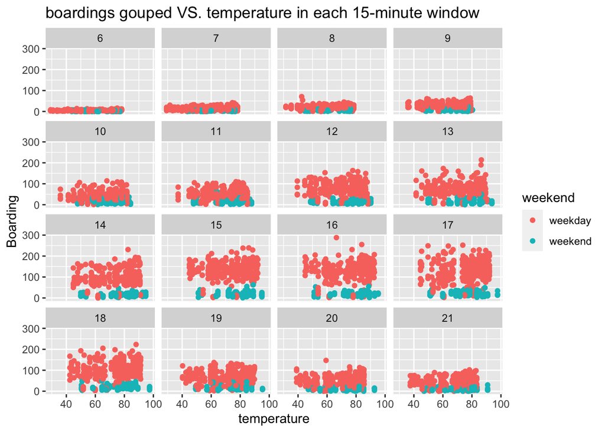

When we hold hour of day and weekend status constant, temperature seems to have a no effect on the number of UT students riding the bus. But there is a big effect for bordings depends on weekday or weekend.

## Problem 2

[output not shown]

[output cut: 346 more lines]

[output not shown]

[output not shown]

[output cut: 58 more lines]

[output not shown]

[output not shown]

[output cut: 540 more lines]

[output not shown]

```
## [1] 70363.4
```

```
## [1] 83881.47
```

```
## [1] 68222.98
```

```
## [1] 68098.53
```

```
## lm(formula = price ~ livingArea + centralAir + bathrooms + bedrooms +
##     rooms + heating + lotSize + livingArea:centralAir + bathrooms:heating +
##     centralAir:bedrooms + livingArea:bathrooms + bedrooms:rooms +
##     livingArea:rooms + livingArea:lotSize + centralAir:lotSize +
##     centralAir:bathrooms + bedrooms:lotSize, data = saratoga_train)
```

```
##                      (Intercept)                       livingArea
##                    -16056.457423                        67.898748
##                     centralAirNo                        bathrooms
##                     27298.827902                     35863.865680
##                         bedrooms                            rooms
##                      2173.227599                      6003.526590
##           heatinghot water/steam                  heatingelectric
##                     29322.848702                     25287.514411
##                          lotSize          livingArea:centralAirNo
##                     31731.685349                       -26.538132
## bathrooms:heatinghot water/steam        bathrooms:heatingelectric
##                    -17538.370610                    -25024.659201
##            centralAirNo:bedrooms             livingArea:bathrooms
##                     11887.012893                         1.275356
##                   bedrooms:rooms                 livingArea:rooms
##                     -3402.970594                         4.961729
##               livingArea:lotSize             centralAirNo:lotSize
##                       -15.943791                    -18148.897461
##           centralAirNo:bathrooms                 bedrooms:lotSize
##                    -12393.449256                      4893.846018
```

```
## Start:  AIC=31796.17
## price ~ 1
##
##              Df  Sum of Sq        RSS   AIC
## + livingArea  1 6.9276e+12 6.4057e+12 30784
## + bathrooms   1 4.8719e+12 8.4614e+12 31169
## + rooms       1 3.9567e+12 9.3766e+12 31311
## + bedrooms    1 2.0900e+12 1.1243e+13 31562
## + fireplaces  1 1.9304e+12 1.1403e+13 31582
## + centralAir  1 1.5507e+12 1.1783e+13 31627
## + fuel        2 9.3267e+11 1.2401e+13 31700
## + heating     2 8.5581e+11 1.2478e+13 31708
## + age         1 4.9979e+11 1.2834e+13 31745
## + lotSize     1 2.9503e+11 1.3038e+13 31767
## <none>                     1.3333e+13 31796
##
## Step:  AIC=30784.33
## price ~ livingArea
##
##              Df  Sum of Sq        RSS   AIC
## + centralAir  1 2.0293e+11 6.2028e+12 30742
## + bathrooms   1 1.9384e+11 6.2119e+12 30744
## + bedrooms    1 1.0762e+11 6.2981e+12 30763
## + heating     2 1.0933e+11 6.2964e+12 30764
## + age         1 5.1023e+10 6.3547e+12 30775
## + fuel        2 4.6817e+10 6.3589e+12 30778
## + lotSize     1 2.8219e+10 6.3775e+12 30780
## + fireplaces  1 1.5435e+10 6.3903e+12 30783
## + rooms       1 1.0995e+10 6.3947e+12 30784
## <none>                     6.4057e+12 30784
##
## Step:  AIC=30741.81
## price ~ livingArea + centralAir
##
##              Df  Sum of Sq        RSS   AIC
## + bathrooms   1 1.2476e+11 6.0780e+12 30716
## + bedrooms    1 6.9857e+10 6.1329e+12 30728
## + lotSize     1 3.5363e+10 6.1674e+12 30736
## + heating     2 3.9403e+10 6.1634e+12 30737
## + rooms       1 1.6711e+10 6.1861e+12 30740
```

[output cut: 46 more lines]

```
## + heating     2 4.6396e+10 5.8607e+12 30675
## + fuel        2 4.2803e+10 5.8643e+12 30676
## <none>                     5.9071e+12 30682
## + age         1 1.6188e+09 5.9055e+12 30684
## + fireplaces  1 7.2151e+06 5.9071e+12 30684
##
## Step:  AIC=30675.35
## price ~ livingArea + centralAir + bathrooms + bedrooms + rooms +
##     lotSize + heating
##
##              Df  Sum of Sq        RSS   AIC
## <none>                     5.8607e+12 30675
## + age         1  842371834 5.8598e+12 30677
## + fireplaces  1    5560068 5.8607e+12 30677
## + fuel        2 7772333351 5.8529e+12 30678
```

```
## lm(formula = price ~ livingArea + centralAir + bathrooms + bedrooms +
##     rooms + lotSize + heating, data = saratoga_train)
```

```
##            (Intercept)             livingArea           centralAirNo
##            38900.81984               92.53295           -16349.30911
##              bathrooms               bedrooms                  rooms
##            21949.10188           -16536.95822             4501.66471
##                lotSize heatinghot water/steam        heatingelectric
##             7227.83915            -8542.06779           -15845.68354
```

```
## [1] 10
```

```
## [1] 70846.57
```

## Problem 3

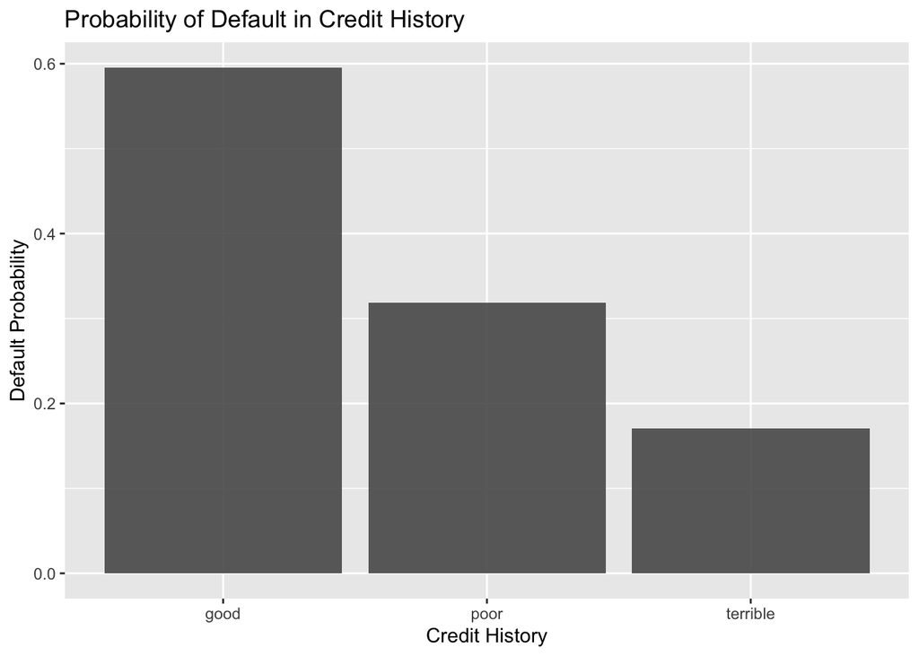

```
##
## Call:
## glm(formula = Default ~ duration + amount + installment + age +
##     history + purpose + foreign, family = binomial, data = german_credit)
##
## Deviance Residuals:
##     Min       1Q   Median       3Q      Max
## -2.3464  -0.8050  -0.5751   1.0250   2.4767
##
## Coefficients:
##                       Estimate Std. Error z value Pr(>|z|)
## (Intercept)         -7.075e-01  4.726e-01  -1.497  0.13435
## duration             2.526e-02  8.100e-03   3.118  0.00182 **
## amount               9.596e-05  3.650e-05   2.629  0.00856 **
## installment          2.216e-01  7.626e-02   2.906  0.00366 **
## age                 -2.018e-02  7.224e-03  -2.794  0.00521 **
## historypoor         -1.108e+00  2.473e-01  -4.479 7.51e-06 ***
## historyterrible     -1.885e+00  2.822e-01  -6.679 2.41e-11 ***
## purposeedu           7.248e-01  3.707e-01   1.955  0.05058 .
## purposegoods/repair  1.049e-01  2.573e-01   0.408  0.68346
## purposenewcar        8.545e-01  2.773e-01   3.081  0.00206 **
## purposeusedcar      -7.959e-01  3.598e-01  -2.212  0.02694 *
## foreigngerman       -1.265e+00  5.773e-01  -2.191  0.02849 *
## ---
## Signif. codes:  0 '***' 0.001 '**' 0.01 '*' 0.05 '.' 0.1 ' ' 1
##
## (Dispersion parameter for binomial family taken to be 1)
##
##     Null deviance: 1221.7  on 999  degrees of freedom
## Residual deviance: 1070.0  on 988  degrees of freedom
## AIC: 1094
##
## Number of Fisher Scoring iterations: 4
```

1)Banks provide a large number of loans to people with good credit records, but rarely provide loans to people with poor credit records. Since defaults rarely occur, the bank conducted a sample survey of a group of default loans. Banks try to match each default behavior with similar loan groups that have not yet defaulted, resulting in a large number of default over-sampling. According to the chart produced, the lower the historical credit of the borrower, the lower the probability of default. 2)I think this data set is not suitable for constructing the default prediction model because there are a large number of default values oversampling. In my opinion, I suggest that banks should reduce the default sample and increase the use of proportional sampling, which may be more suitable for default prediction models.

## Problem 4: Children and hotel reservations

#Model Building

#1.baseline model 1: A small model that uses only the market segment, adults, customer type and repeated guest variables as features

```
##
## Call:
## lm(formula = children ~ market_segment + adults + customer_type +
##     is_repeated_guest, data = hotels_dev)
##
## Residuals:
##      Min       1Q   Median       3Q      Max
## -0.18090 -0.11264 -0.09334 -0.02648  1.03181
##
## Coefficients:
##                               Estimate Std. Error t value Pr(>|t|)
## (Intercept)                  -0.021617   0.026517  -0.815  0.41496
## market_segmentComplementary   0.083585   0.028858   2.896  0.00378 **
## market_segmentCorporate       0.014249   0.025924   0.550  0.58257
## market_segmentDirect          0.112807   0.025711   4.388 1.15e-05 ***
## market_segmentGroups          0.006855   0.026003   0.264  0.79207
## market_segmentOffline_TA/TO   0.021254   0.025697   0.827  0.40817
## market_segmentOnline_TA       0.079756   0.025598   3.116  0.00184 **
## adults                        0.017600   0.002679   6.570 5.08e-11 ***
## customer_typeGroup           -0.014206   0.016287  -0.872  0.38310
## customer_typeTransient        0.019305   0.006941   2.781  0.00542 **
## customer_typeTransient-Party -0.008360   0.007363  -1.135  0.25625
## is_repeated_guest            -0.043892   0.006823  -6.433 1.26e-10 ***
## ---
## Signif. codes:  0 '***' 0.001 '**' 0.01 '*' 0.05 '.' 0.1 ' ' 1
##
## Residual standard error: 0.2683 on 44988 degrees of freedom
## Multiple R-squared:  0.03091,    Adjusted R-squared:  0.03067
## F-statistic: 130.5 on 11 and 44988 DF,  p-value: < 2.2e-16
```

```
## [1] 0.2671723
```

For baseline model 1, the Root mean squared error is 0.27.

#2.baseline 2: a big model that uses all the possible predictors expect the arrival data variable

```
##
## Call:
## lm(formula = children ~ . - arrival_date, data = hotels_dev)
##
## Residuals:
##      Min       1Q   Median       3Q      Max
## -0.94651 -0.08371 -0.03812  0.00843  1.08354
##
## Coefficients:
##                                      Estimate Std. Error t value Pr(>|t|)
## (Intercept)                        -5.776e-02  2.337e-02  -2.471 0.013466 *
## hotelResort_Hotel                  -3.308e-02  2.878e-03 -11.494  < 2e-16 ***
## lead_time                           3.980e-05  1.428e-05   2.788 0.005309 **
## stays_in_weekend_nights             3.577e-03  1.314e-03   2.723 0.006481 **
## stays_in_week_nights               -8.994e-04  7.131e-04  -1.261 0.207195
## adults                             -3.801e-02  2.525e-03 -15.054  < 2e-16 ***
## mealFB                              4.685e-02  1.713e-02   2.735 0.006247 **
## mealHB                              2.647e-05  3.680e-03   0.007 0.994261
## mealSC                             -5.305e-02  4.243e-03 -12.501  < 2e-16 ***
## mealUndefined                       2.224e-02  1.081e-02   2.057 0.039674 *
## market_segmentComplementary         5.264e-02  2.675e-02   1.967 0.049137 *
## market_segmentCorporate             4.656e-02  2.269e-02   2.052 0.040148 *
## market_segmentDirect                4.784e-02  2.446e-02   1.955 0.050537 .
## market_segmentGroups                5.893e-02  2.377e-02   2.479 0.013183 *
## market_segmentOffline_TA/TO         7.127e-02  2.383e-02   2.991 0.002778 **
## market_segmentOnline_TA             6.539e-02  2.378e-02   2.750 0.005955 **
## distribution_channelDirect          1.895e-02  1.023e-02   1.853 0.063846 .
## distribution_channelGDS            -7.584e-02  2.498e-02  -3.036 0.002397 **
## distribution_channelTA/TO           1.234e-03  8.515e-03   0.145 0.884781
## is_repeated_guest                  -3.085e-02  6.464e-03  -4.772 1.83e-06 ***
## previous_cancellations              6.904e-04  4.394e-03   0.157 0.875134
## previous_bookings_not_canceled     -2.246e-03  8.044e-04  -2.792 0.005233 **
## reserved_room_typeB                 2.080e-01  1.349e-02  15.427  < 2e-16 ***
## reserved_room_typeC                 5.368e-01  1.439e-02  37.294  < 2e-16 ***
## reserved_room_typeD                -6.700e-02  4.305e-03 -15.564  < 2e-16 ***
## reserved_room_typeE                -2.557e-02  7.755e-03  -3.297 0.000978 ***
## reserved_room_typeF                 3.079e-01  1.155e-02  26.656  < 2e-16 ***
## reserved_room_typeG                 4.306e-01  1.560e-02  27.598  < 2e-16 ***
## reserved_room_typeH                 6.009e-01  2.906e-02  20.677  < 2e-16 ***
## reserved_room_typeL                -8.549e-02  1.649e-01  -0.518 0.604254
```

[output cut: 10 more lines]

```
## deposit_typeNon_Refund              2.774e-02  3.008e-02   0.922 0.356523
## deposit_typeRefundable              2.127e-02  2.585e-02   0.823 0.410516
## days_in_waiting_list               -2.472e-05  7.717e-05  -0.320 0.748751
## customer_typeGroup                 -4.031e-03  1.425e-02  -0.283 0.777185
## customer_typeTransient              1.257e-02  6.150e-03   2.043 0.041032 *
## customer_typeTransient-Party       -2.955e-02  6.644e-03  -4.447 8.72e-06 ***
## average_daily_rate                  8.754e-04  2.960e-05  29.575  < 2e-16 ***
## required_car_parking_spacesparking -3.406e-04  3.893e-03  -0.087 0.930277
## total_of_special_requests           3.268e-02  1.499e-03  21.796  < 2e-16 ***
## ---
## Signif. codes:  0 '***' 0.001 '**' 0.01 '*' 0.05 '.' 0.1 ' ' 1
##
## Residual standard error: 0.2331 on 44951 degrees of freedom
## Multiple R-squared:  0.2691, Adjusted R-squared:  0.2683
## F-statistic: 344.8 on 48 and 44951 DF,  p-value: < 2.2e-16
```

```
## [1] 0.2350748
```

For baseline model 2, the Root mean squared error is 0.23.

```
##
## Call:
## lm(formula = children ~ hotel + lead_time + meal + stays_in_weekend_nights +
##     stays_in_week_nights + adults + market_segment + is_repeated_guest +
##     log(1 + previous_bookings_not_canceled) + reserved_room_type +
##     deposit_type + assigned_room_type + customer_type + average_daily_rate +
##     days_in_waiting_list + total_of_special_requests, data = hotels_dev)
##
## Residuals:
##      Min       1Q   Median       3Q      Max
## -0.92907 -0.08312 -0.03851  0.00748  1.08750
##
## Coefficients:
##                                           Estimate Std. Error t value Pr(>|t|)
## (Intercept)                             -5.683e-02  2.340e-02  -2.428 0.015185
## hotelResort_Hotel                       -3.244e-02  2.803e-03 -11.573  < 2e-16
## lead_time                                5.121e-05  1.427e-05   3.589 0.000332
## mealFB                                   5.528e-02  1.712e-02   3.228 0.001246
## mealHB                                   1.295e-03  3.675e-03   0.352 0.724516
## mealSC                                  -5.310e-02  4.248e-03 -12.501  < 2e-16
## mealUndefined                            2.481e-02  1.077e-02   2.304 0.021246
## stays_in_weekend_nights                  3.907e-03  1.315e-03   2.972 0.002956
## stays_in_week_nights                     2.982e-05  7.101e-04   0.042 0.966496
## adults                                  -4.037e-02  2.515e-03 -16.049  < 2e-16
## market_segmentComplementary              7.367e-02  2.548e-02   2.891 0.003842
## market_segmentCorporate                  5.273e-02  2.275e-02   2.318 0.020448
## market_segmentDirect                     6.910e-02  2.249e-02   3.072 0.002127
## market_segmentGroups                     6.307e-02  2.280e-02   2.766 0.005683
## market_segmentOffline_TA/TO              6.960e-02  2.249e-02   3.094 0.001976
## market_segmentOnline_TA                  6.540e-02  2.241e-02   2.919 0.003516
## is_repeated_guest                       -1.432e-02  7.869e-03  -1.820 0.068721
## log(1 + previous_bookings_not_canceled) -2.505e-02  5.199e-03  -4.818 1.46e-06
## reserved_room_typeB                      2.123e-01  1.350e-02  15.720  < 2e-16
## reserved_room_typeC                      5.370e-01  1.442e-02  37.255  < 2e-16
## reserved_room_typeD                     -6.916e-02  4.309e-03 -16.050  < 2e-16
## reserved_room_typeE                     -2.965e-02  7.763e-03  -3.819 0.000134
## reserved_room_typeF                      3.062e-01  1.157e-02  26.456  < 2e-16
## reserved_room_typeG                      4.276e-01  1.563e-02  27.365  < 2e-16
## reserved_room_typeH                      6.027e-01  2.910e-02  20.707  < 2e-16
## reserved_room_typeL                     -9.311e-02  1.652e-01  -0.563 0.573100
```

[output cut: 52 more lines]

```
## assigned_room_typeH                     **
## assigned_room_typeI                     ***
## assigned_room_typeK                     *
## customer_typeGroup
## customer_typeTransient                  *
## customer_typeTransient-Party            ***
## average_daily_rate                      ***
## days_in_waiting_list
## total_of_special_requests               ***
## ---
## Signif. codes:  0 '***' 0.001 '**' 0.01 '*' 0.05 '.' 0.1 ' ' 1
##
## Residual standard error: 0.2335 on 44957 degrees of freedom
## Multiple R-squared:  0.2663, Adjusted R-squared:  0.2656
## F-statistic: 388.6 on 42 and 44957 DF,  p-value: < 2.2e-16
```

```
## [1] 0.2356288
```

#Model Validation: Step 1 In model validation step 1, we plot the ROC curves for our best model with data in hotels_val, with threshold vary from [0, 1]

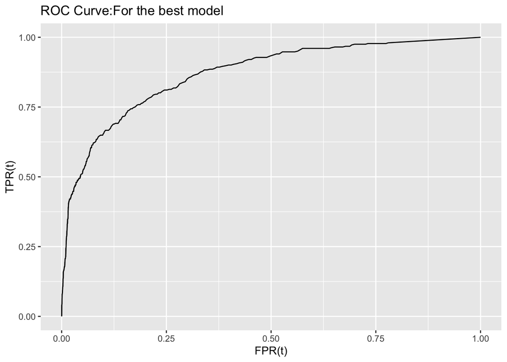

#Model Validation: Step 2

```
##     Min.  1st Qu.   Median     Mean  3rd Qu.     Max.
## -0.16849  0.01017  0.05232  0.08450  0.10164  0.93795
```

```
## # A tibble: 20 x 4
##    fold_id True_Probability Predicted_Probability Residual
##  *   <int>            <int>                 <int>    <int>
##  1       1               22                    12       10
##  2       2               13                     9        4
##  3       3               24                    24        0
##  4       4               20                    13        7
##  5       5               21                    16        5
##  6       6               21                    11       10
##  7       7               18                    16        2
##  8       8               25                    14       11
##  9       9               21                    15        6
## 10      10               10                     8        2
## 11      11               22                    19        3
## 12      12               23                    13       10
## 13      13                9                     7        2
## 14      14               16                    15        1
## 15      15               25                    17        8
## 16      16               21                    13        8
## 17      17               21                    15        6
## 18      18               20                    12        8
## 19      19               27                    14       13
## 20      20               23                    14        9
```

In model validation step 2, we create 20 folds of hotels_Val and each fold have about 250 bookings in it,for each fold predict whether each booking will have children on it, sum up the predicted probability for all the bookings in the fold and compare this “expected” number of bookings with children versus the actual number of bookings with children in that fold.The error of my model do at predicting is shown above, there is a 0, and there are some large residual. However, I think the model do a great job.